# Assignment 6_update

1. Scrap the data (all the numbers) for the past 14 days in the following website and plot all the numbers in the tables. Plot all the Temp, Wind, Humidity, Barometer and Visibility against Time with labels and units. Get the correct queries of the URL for the past 14 days which keep changing daily relative to when your code is run. More details have been given in lecture 10.  
   https://www.timeanddate.com/weather/hong-kong/hong-kong/historic  
   Your output should look like this:

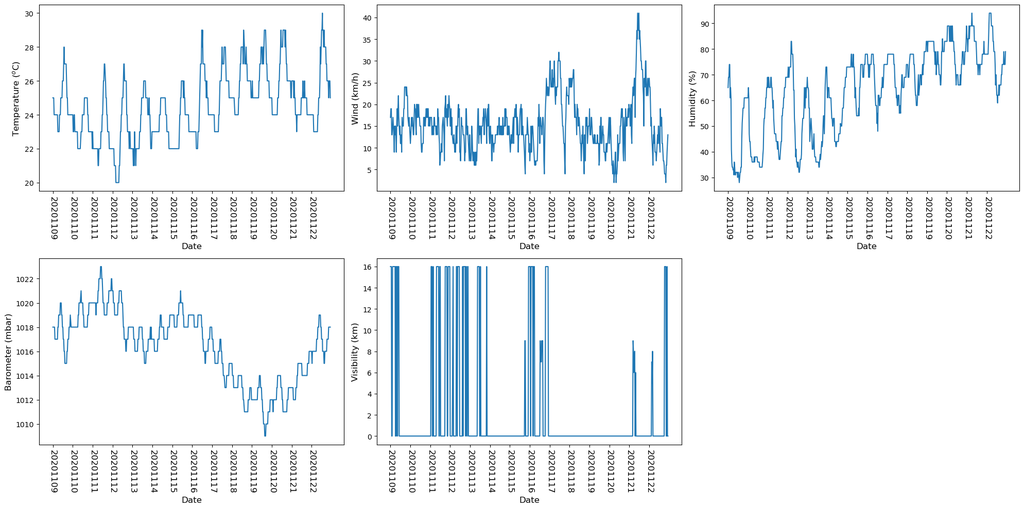

```python
# Q1 code

import requests
from bs4 import BeautifulSoup
import matplotlib.pyplot as plt
import numpy as np
import datetime

alldate=[]
today = datetime.date.today()

for n in range(13,-1,-1):
    alldate.append((today-datetime.timedelta(days=n)).strftime('%Y%m%d'))

alltime=[]
alltemp=[]
allwind=[]
allhumidity=[]
allbar=[]
allvis=[]

ndt=0
for dt in alldate:

    url = 'https://www.timeanddate.com/weather/hong-kong/hong-kong/historic' + '?hd='+dt
    r = requests.get(url)
    html_contents = r.text
    html_soup = BeautifulSoup(html_contents, 'html.parser')

    table_body = html_soup.find('table', id="wt-his").find('tbody')

    for row in table_body.find_all('tr'):
        tmp=row.find('th').text
        alltime.append(float(tmp[0:2]+'.'+str(int(int(tmp[3:5])/6)))+24*ndt)
        values = row.find_all('td')
        alltemp.append(float(values[1].text[0:2]))
        allwind.append(float(values[3].text[0:2]))
        allhumidity.append(float(values[5].text[0:2]))
        allbar.append(float(values[6].text[0:4]))
        try:
            allvis.append(float(values[7].text[0:2]))
        except:
            allvis.append(0)
    ndt=ndt+1

f = plt.figure(figsize=(20,10), dpi=100)

# temp vs time
ax1 = plt.subplot(231)
ax1.plot(alltime,alltemp)
ax1.set_xticks(np.linspace(0,ndt*24,ndt,endpoint=False))
ax1.set_xticklabels(alldate,rotation=-90,fontsize=12)
ax1.set_xlabel('Date',fontsize=12)
ax1.set_ylabel('Temperature ($^o$C)',fontsize=12)

# wind vs time
ax2 = plt.subplot(232)
ax2.plot(alltime,allwind)
ax2.set_xticks(np.linspace(0,ndt*24,ndt,endpoint=False))
ax2.set_xticklabels(alldate,rotation=-90,fontsize=12)
ax2.set_xlabel('Date',fontsize=12)
ax2.set_ylabel('Wind (km/h)',fontsize=12)

# humidity vs time
ax3 = plt.subplot(233)
ax3.plot(alltime,allhumidity)
ax3.set_xticks(np.linspace(0,ndt*24,ndt,endpoint=False))
ax3.set_xticklabels(alldate,rotation=-90,fontsize=12)
ax3.set_xlabel('Date',fontsize=12)
ax3.set_ylabel('Humidity (%)',fontsize=12)

# Barometer vs time
ax4 = plt.subplot(234)
ax4.plot(alltime,allbar)
ax4.set_xticks(np.linspace(0,ndt*24,ndt,endpoint=False))
ax4.set_xticklabels(alldate,rotation=-90,fontsize=12)
ax4.set_xlabel('Date',fontsize=12)
ax4.set_ylabel('Barometer (mbar)',fontsize=12)

# visibilty vs time
ax5 = plt.subplot(235)
ax5.plot(alltime,allvis)
ax5.set_xticks(np.linspace(0,ndt*24,ndt,endpoint=False))
ax5.set_xticklabels(alldate,rotation=-90,fontsize=12)
ax5.set_xlabel('Date',fontsize=12)
ax5.set_ylabel('Visibility (km)',fontsize=12)

plt.tight_layout()
```

1. Scrap the following CSV file updated daily online to draw the always up-to-date Epidemic curve like below for Hong Kong. Also, plot in one figure the up-to-date cumulative cases separated into Imported (Imported case plus Epidemiologically linked with imported case) and Local (all the rest) against the Date of onset (skip Asymptomatic, etc.) like the next figure. Bonus points will be given for any meaningful extrapolation to predict the future local cases. Furthermore, draw a histogram of the Deceased cases against Age in bins of 10 years old and the death rate % within each of the age groups (i.e. deaths÷cases in the age group only) in the same figure. Lastly, display the up-to-date Table 1 like below for the last Report day using `pandas`.  
   http://www.chp.gov.hk/files/misc/enhanced_sur_covid_19_eng.csv

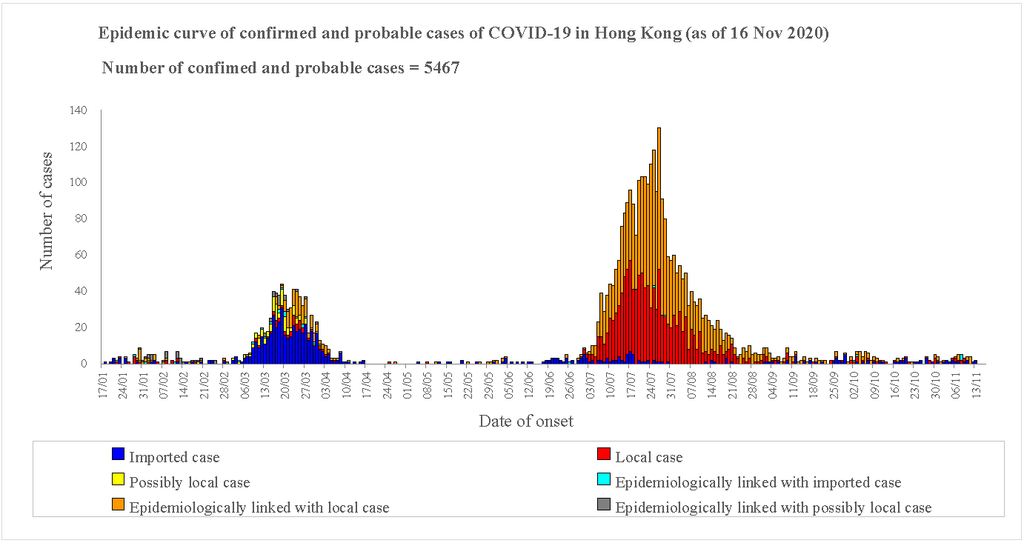

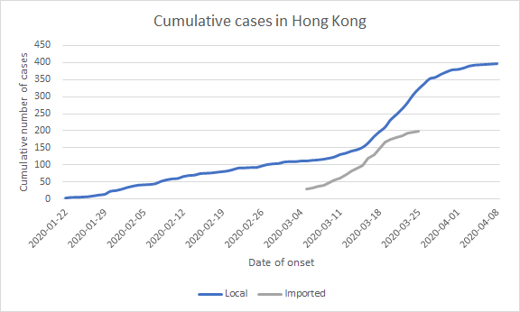

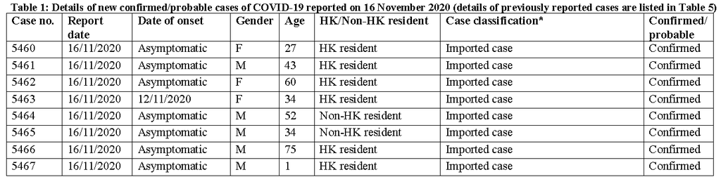

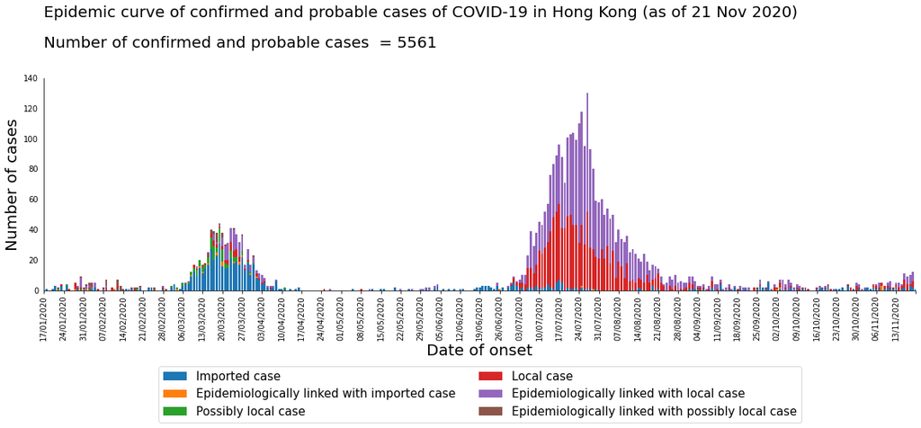

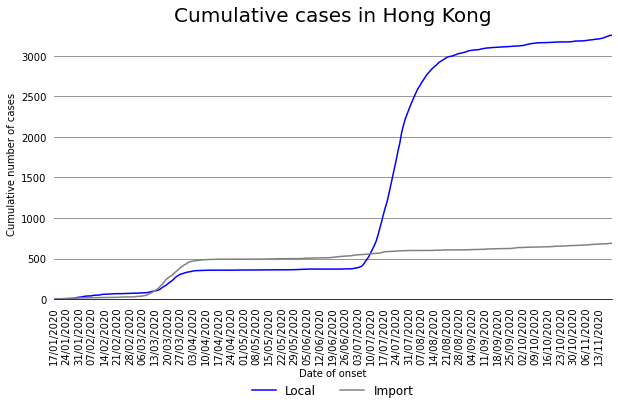

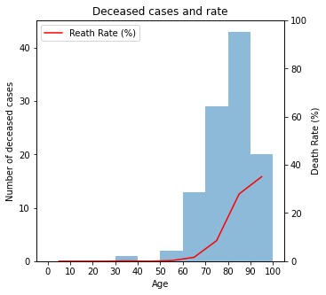

```python
# Q2 Code
import requests
import matplotlib.pyplot as plt
import numpy as np
import pandas as pd
import datetime
import math

def is_valid_date(d):
    try:
        d1 = datetime.datetime.strptime(d, '%d/%m/%Y')
        return True
    except:
        return False

url = 'http://www.chp.gov.hk/files/misc/enhanced_sur_covid_19_eng.csv'

r = requests.get(url)
data = r.text.split('\r\n')
data1 = [data[i].split(',') for i in range(len(data))]
df = pd.DataFrame(data1[1:len(data1)-1],columns=data1[0])
report_date = max(df['Report date'].apply(lambda x: datetime.datetime.strptime(x, '%d/%m/%Y')))
df_date = df[df['Date of onset'].apply(lambda x: is_valid_date(x))]
dates=df_date['Date of onset'].apply(lambda x: datetime.datetime.strptime(x, '%d/%m/%Y'))
day1 = min(dates)
dayn = max(dates)
delta = (dayn - day1).days+1
all_dates = [(day1+datetime.timedelta(days=i-1)).strftime('%d/%m/%Y') for i in range(delta+2)]
labels = list(df_date['Case classification*'].unique())
counts = np.zeros([len(labels),len(all_dates)])
for i in range(len(all_dates)):
    for j in range(len(labels)):
        counts[j,i]=df_date['Case no.'][df_date['Date of onset']==all_dates[i]][df_date['Case classification*']==labels[j]].count()
# Plot 1
f = plt.figure(figsize=(20,5))
ax = plt.subplot()
xx = np.linspace(0,len(all_dates)-1,len(all_dates))
for i in range(len(labels)):
    if i==0:
        ax.bar(xx,counts[i],label=labels[i])
        bottoms = counts[i].copy()
    else:
        ax.bar(xx,counts[i],bottom=bottoms,label=labels[i])
        bottoms += counts[i]
ax.text(0,180,'Epidemic curve of confirmed and probable cases of COVID-19 in Hong Kong (as of {})'.format(report_date.strftime('%d %b %Y')),fontsize=20)
ax.text(0,160,'Number of confirmed and probable cases  = {}'.format(df.shape[0]),fontsize=20)
ax.set_xlim(0,delta)
ax.set_ylim(0,max(counts.sum(axis=0))+10)
label_date = [all_dates[i] for i in range(delta) if i%7==0]
ax.set_xticks(np.linspace(0,int(delta/7)*7,int(delta/7)+1))
ax.set_xticklabels(label_date,rotation=90)
ax.spines['top'].set_visible(False)
ax.spines['right'].set_visible(False)
plt.tick_params(axis='y',
                which='both',
                left=False,
                labelleft=True,
                )
ax.set_xlabel('Date of onset',fontsize=20)
ax.set_ylabel('Number of cases',fontsize=20)
plt.legend(loc='lower center',ncol=2,bbox_to_anchor=(0.5, -0.65),fontsize=15)

# Plot 2
import_index = [i for i in range(len(labels)) if labels[i] in ['Imported case','Epidemiologically linked with imported case' ]]
ic = np.zeros(len(all_dates))
for i in import_index:
    ic+=counts[i]
lc = counts.sum(axis=0) - ic
cic = 0
clc = 0
cumulative_cases = np.zeros([2,len(all_dates)])
for i in range(len(all_dates)):
    cumulative_cases[0,i] = ic[i]+cic
    cic += ic[i]
    cumulative_cases[1,i] = lc[i]+clc
    clc += lc[i]
f1 = plt.figure(figsize=(10,5))
ax1 = plt.subplot()
ax1.set_title('Cumulative cases in Hong Kong',fontsize=20)
ax1.set_xlim(0,delta)
ax1.set_ylim(0,cumulative_cases.max()+100)
ax1.plot(xx,cumulative_cases[1],label='Local',c='b')
ax1.plot(xx,cumulative_cases[0],label='Import',c='grey')
ax1.set_xticks(np.linspace(0,int(delta/7)*7,int(delta/7)+1))
ax1.set_xticklabels(label_date,rotation=90)
ax1.set_xlabel('Date of onset')
ax1.set_ylabel('Cumulative number of cases')
ax1.spines['top'].set_visible(False)
ax1.spines['left'].set_visible(False)
ax1.spines['right'].set_visible(False)
ax1.grid(b=True, axis = 'y', which='major', c='grey', linestyle='-')
plt.tick_params(axis='both',
                which='both',
                left=False,
                bottom=False,
                labelleft=True,
                labelbottom=True
                )
plt.legend(loc='lower center',frameon=False,ncol=2,bbox_to_anchor=(0.5, -0.4),fontsize=12)

# Plot 3
f2 = plt.figure(figsize=(5,5))
df_deceased = df[df['Hospitalised/Discharged/Deceased']=='Deceased']
age_max = df_deceased['Age'].apply(int).max()
bin_list = list(range(0,math.ceil(age_max/10)*10+1,math.ceil(age_max/10)))
ax2 = plt.subplot()
all_ages = list(df['Age'].apply(int))
deceassed_ages = list(df_deceased['Age'].apply(int))
result = plt.hist(deceassed_ages,bins=bin_list,alpha=0.5)
ax2.set_title('Deceased cases and rate')
ax2.set_xticks(bin_list)
ax2.set_xlabel('Age')
ax2.set_ylabel('Number of deceased cases')
dead_age_count = result[0]
all_age_count = np.histogram(all_ages,bins=bin_list)[0]
death_rate = (dead_age_count/all_age_count*100).round(2)
ax2t = ax2.twinx()
ax2t.plot([i+5 for i in bin_list[:-1]],death_rate,c='r',label='Reath Rate (%)')
ax2t.set_ylim(0,100)
ax2t.set_ylabel('Death Rate (%)')
plt.legend(loc='upper left')
print()
```

```python
# Q2 Code to Print Table
cols = ['Case no.','Report date','Date of onset','Gender','Age','HK/Non-HK resident','Case classification*','Confirmed/probable']
print(df[cols][df['Report date']==report_date.strftime('%d/%m/%Y')].set_index('Case no.'))
```

```
         Report date Date of onset Gender Age HK/Non-HK resident  \
Case no.
5519      21/11/2020    19/11/2020      F  44        HK resident
5520      21/11/2020    17/11/2020      F  60        HK resident
5521      21/11/2020    13/11/2020      M  39        HK resident
5522      21/11/2020    11/11/2020      F  25        HK resident
5523      21/11/2020    16/11/2020      M  66        HK resident
5524      21/11/2020    13/11/2020      M  57        HK resident
5525      21/11/2020    19/11/2020      F  31        HK resident
5526      21/11/2020    05/11/2020      F  71        HK resident
5527      21/11/2020  Asymptomatic      F  36        HK resident
5528      21/11/2020    20/11/2020      F  18        HK resident
5529      21/11/2020    16/11/2020      F  62        HK resident
5530      21/11/2020  Asymptomatic      M  79        HK resident
5531      21/11/2020    17/11/2020      M  24        HK resident
```

[output cut: 76 more lines]

1. Scrap the below CSV file updated daily online to draw the always up-to-date cumulative cases in log<sub>10</sub> scale from 2020-1-23 for all individual Country/Region (not Province/State) but single out Hong Kong. Add to the plot a black line showing the up-to-date global total deaths by scraping the first table in the second URL. Generate a second figure by adjusting the x-axis to the number of days since 1000th case for each Country/Region and HK.
   - https://raw.githubusercontent.com/CSSEGISandData/COVID-19/master/csse_covid_19_data/csse_covid_19_time_series/time_series_covid19_confirmed_global.csv
   - https://www.worldometers.info/coronavirus/worldwide-graphs/

   Your output should look like these from https://ig.ft.com/coronavirus-chart/:

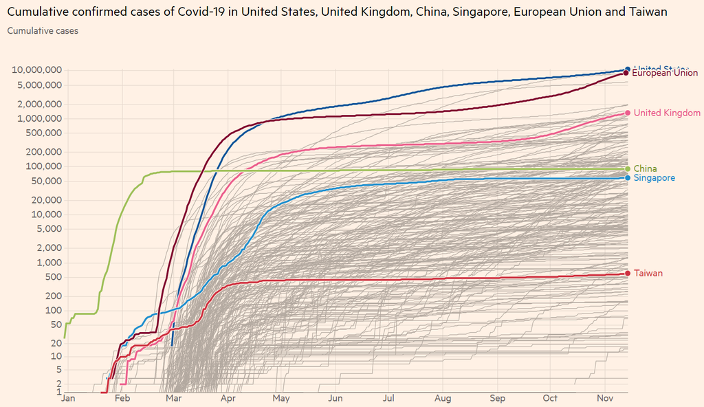

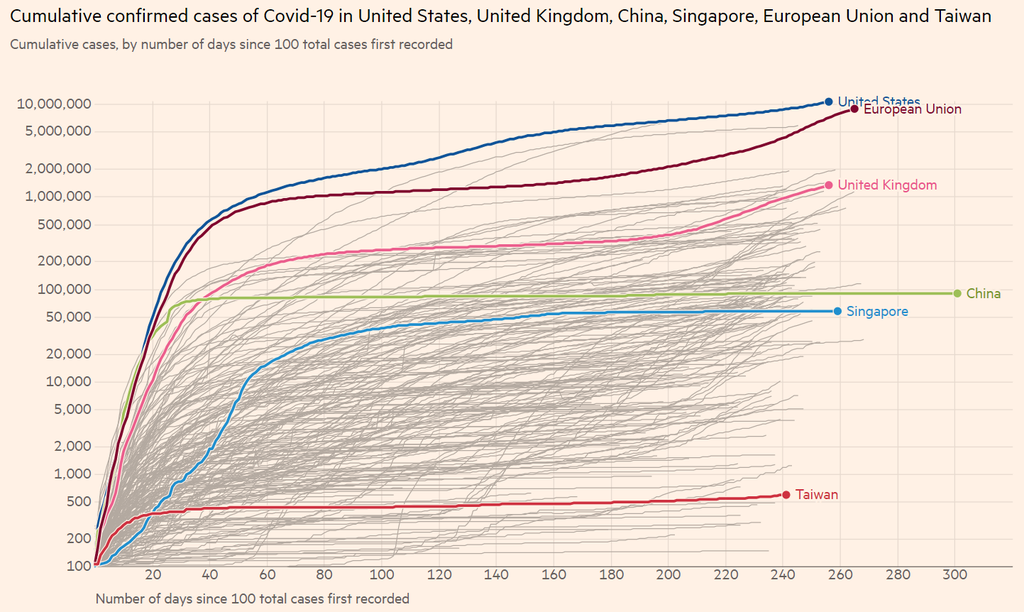

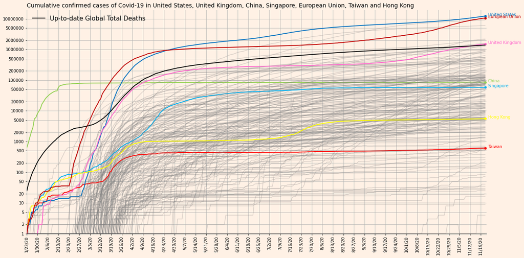

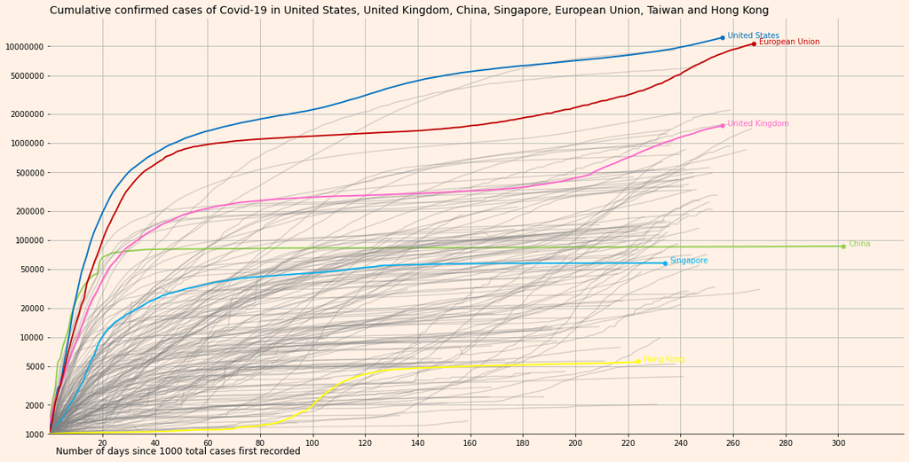

```python
# Q3 Code
# Q3 Code
import requests
import matplotlib.pyplot as plt
from bs4 import BeautifulSoup
import numpy as np
import pandas as pd
import datetime
import math
from numpy import *

eu_all = ['Austria', 'Belgium', 'Bulgaria', 'Croatia', 'Cyprus',
      'Czechia', 'Denmark', 'Estonia', 'Finland', 'France',
      'Germany', 'Greece', 'Hungary', 'Ireland', 'Italy',
      'Latvia', 'Lithuania', 'Luxembourg', 'Malta',
      'Netherlands', 'Poland', 'Portugal', 'Romania',
      'Slovakia', 'Slovenia', 'Spain', 'Sweden']

url = 'https://raw.githubusercontent.com/CSSEGISandData/COVID-19/master/csse_covid_19_data/csse_covid_19_time_series/time_series_covid19_confirmed_global.csv'
url1 = 'https://www.worldometers.info/coronavirus/worldwide-graphs/'

r = requests.get(url)
data = r.text.split('\n')
data1 = [data[i].split(',') for i in range(len(data))]


# Plot 1
ncols = len(data1[0])
for i in range(len(data1)-1):
    if len(data1[i]) > ncols:
        c=0
        while '"' not in data1[i][c]:
            c+=1
        temp = data1[i].pop(c)
        data1[i][c]=temp+","+data1[i][c]

df = pd.DataFrame(data1[1:len(data1)-1],columns=data1[0])
for c in df.columns:
    df[c] = df[c].apply(pd.to_numeric,errors='ignore')

hk_index = list(df.index[df['Province/State']=='Hong Kong'])[0]
hk = df.iloc[hk_index][5:]
df = df.drop(index = hk_index)
df_cum = df.groupby('Country/Region').sum()
df_cum_log = df_cum.T.apply(np.log10).replace(-inf,0).iloc[3:,:]
hk_log = hk.apply(lambda x: np.log10(x)).replace(-inf,0)
eu = df_cum.T[eu_all].sum(axis=1)[3:]
eu_log = eu.apply(np.log10).replace(-inf,0)
dates = list(df_cum_log.index)
day1 = datetime.datetime.strptime(dates[0], '%m/%d/%y')
dayn = datetime.datetime.strptime(dates[-1], '%m/%d/%y')
ndays = (dayn-day1).days+1
label_date = [dates[i] for i in range(ndays) if i%7==0]
x = np.linspace(0,ndays-1,ndays)
target = {'US':('#0070C0','United States'),
          'European Union':('#C00000','European Union'),
          'United Kingdom':('#FF66CC','United Kingdom'),
          'China':('#92D050','China'),
          'Singapore':('#00B0F0','Singapore'),
          'Taiwan*':('#FF0000','Taiwan'),
          'Hong Kong':('#FFFF00','Hong Kong')}
f = plt.figure(figsize=(20,10))
ax = plt.subplot()
for c in df_cum_log.columns:
    if c in target:
        ax.plot(x,df_cum_log[c],c=target[c][0],linewidth=2)
        ax.plot(x[-1],df_cum_log[c][-1],c=target[c][0],marker='.',markersize=10)
        ax.text(ndays+1,df_cum_log[c][-1],target[c][1],c=target[c][0])
    else:
        ax.plot(x,df_cum_log[c],c='grey',alpha=0.3)
# add plot HK
ax.plot(x,hk_log,c=target['Hong Kong'][0],linewidth=2)
ax.plot(x[-1],hk_log[-1],c=target['Hong Kong'][0],marker='.',markersize=10)
ax.text(ndays+1,hk_log[-1],'Hong Kong',c=target['Hong Kong'][0])
# add plot EU
ax.plot(x,eu_log,c=target['European Union'][0],linewidth=2)
ax.plot(x[-1],eu_log[-1],c=target['European Union'][0],marker='.',markersize=10)
ax.text(ndays+1,eu_log[-1],'European Union',c=target['European Union'][0])
# add plot total deaths
r1 = requests.get(url1)
Soup = BeautifulSoup(r1.text, 'html.parser')
temp = Soup.find_all('table',class_='table table-hover table-bordered table-condensed table-list')[0]
trs = temp.find_all('tr')
total_deaths = []
for row in trs[1:]:
    total_deaths.insert(0,int(row.find_all('td')[1].text.replace(',','')))
td = np.log10(np.array(total_deaths))
ax.plot(x,td,c='k',linewidth=2,label='Up-to-date Global Total Deaths')
# fig control
ax.set_xlim(0,ndays)
ax.set_ylim(0,df_cum_log.max().max()+0.2)
levels = [1,2,5]
ylabels=[]
y = np.zeros((int(df_cum_log.max().max()))*3+1)
for i in range(int(df_cum_log.max().max())):
    for j in range(3):
        y[3*i+j]=i+np.log10(levels[j])
        ylabels.append(levels[j]*10**i)
y[-1] = int(df_cum_log.max().max())
ylabels.append(10**int(df_cum_log.max().max()))
ax.set_title('Cumulative confirmed cases of Covid-19 in United States, United Kingdom, China, Singapore, European Union, Taiwan and Hong Kong',fontsize=14,loc='left')
ax.set_xticks(np.linspace(0,int(ndays/7)*7,int(ndays/7)+1))
ax.set_xticklabels(label_date,rotation=90)
ax.set_yticks(y)
ax.set_yticklabels(ylabels)
ax.set_facecolor('#FFF1E5')
f.set_facecolor('#FFF1E5')
ax.grid()
ax.spines['top'].set_visible(False)
ax.spines['right'].set_visible(False)
ax.spines['left'].set_visible(False)
plt.legend(frameon=False,fontsize=15)

#Plot 2
f1 = plt.figure(figsize=(20,10))
ax1 = plt.subplot()
for idx, c in enumerate(df_cum_log.columns):
    tdf = df_cum.T.iloc[3:,idx]
    if tdf[-1]<1000:
        continue
    day1000 = datetime.datetime.strptime(tdf[tdf>1000].index[0], '%m/%d/%y')
    day_delta = (dayn-day1000).days+1
    day_shift = (day1000-day1).days
    if c in target:
        ax1.plot(x[:day_delta],df_cum_log[c][day_shift:],c=target[c][0],linewidth=2)
        ax1.plot(x[day_delta-1],df_cum_log[c][-1],c=target[c][0],marker='.',markersize=10)
        ax1.text(day_delta+1,df_cum_log[c][-1],target[c][1],c=target[c][0])
    else:
        ax1.plot(x[:day_delta],df_cum_log[c][day_shift:],c='grey',alpha=0.3)
# add plot HK
day1000hk = datetime.datetime.strptime(hk[hk>1000].index[0], '%m/%d/%y')
day_delta = (dayn-day1000hk).days+1
day_shift = (day1000hk-day1).days
ax1.plot(x[:day_delta],hk_log[day_shift:],c=target['Hong Kong'][0],linewidth=2)
ax1.plot(x[day_delta-1],hk_log[-1],c=target['Hong Kong'][0],marker='.',markersize=10)
ax1.text(day_delta+1,hk_log[-1],'Hong Kong',c=target['Hong Kong'][0])
# add plot EU
day1000eu = datetime.datetime.strptime(eu[eu>1000].index[0], '%m/%d/%y')
day_delta = (dayn-day1000eu).days+1
day_shift = (day1000eu-day1).days
ax1.plot(x[:day_delta],eu_log[day_shift:],c=target['European Union'][0],linewidth=2)
ax1.plot(x[day_delta-1],eu_log[-1],c=target['European Union'][0],marker='.',markersize=10)
ax1.text(day_delta+1,eu_log[-1],'European Union',c=target['European Union'][0])
#fig control
ax1.set_xlim(0,ndays+20)
ax1.set_ylim(3,df_cum_log.max().max()+0.2)

ax1.set_title('Cumulative confirmed cases of Covid-19 in United States, United Kingdom, China, Singapore, European Union, Taiwan and Hong Kong',fontsize=14,loc='left')
ax1.set_xticks(np.array([i*20 for i in range(1,int((ndays+20)/20))]))
# ax1.set_xticklabels(label_date,rotation=90)
ax1.set_yticks(y[9:])
ax1.set_yticklabels(ylabels[9:])
ax1.set_facecolor('#FFF1E5')
f1.set_facecolor('#FFF1E5')
ax1.grid()
ax1.spines['top'].set_visible(False)
ax1.spines['right'].set_visible(False)
ax1.spines['left'].set_visible(False)
ax1.set_xlabel('Number of days since 1000 total cases first recorded',fontsize=12)
ax1.xaxis.set_label_coords(0.15, -0.03)
```